# Risk Factor Analysis

## Outcome Variable

**Outcome Variable:** pers_wast

## Predictor Variables

**Intervention Variable:** month

**Adjustment Set:**

unadjusted

## Stratifying Variables

The analysis was stratified on these variable(s):

- agecat
- studyid
- country

## Data Summary

| agecat | studyid | country | month | pers_wast | n_cell | n |
| --- | --- | --- | --- | --- | --- | --- |
| 0-24 months | ki0047075b-MAL-ED | BANGLADESH | 1 | 0 | 20 | 248 |
| 0-24 months | ki0047075b-MAL-ED | BANGLADESH | 1 | 1 | 0 | 248 |
| 0-24 months | ki0047075b-MAL-ED | BANGLADESH | 2 | 0 | 19 | 248 |
| 0-24 months | ki0047075b-MAL-ED | BANGLADESH | 2 | 1 | 1 | 248 |
| 0-24 months | ki0047075b-MAL-ED | BANGLADESH | 3 | 0 | 25 | 248 |
| 0-24 months | ki0047075b-MAL-ED | BANGLADESH | 3 | 1 | 1 | 248 |
| 0-24 months | ki0047075b-MAL-ED | BANGLADESH | 4 | 0 | 21 | 248 |
| 0-24 months | ki0047075b-MAL-ED | BANGLADESH | 4 | 1 | 1 | 248 |
| 0-24 months | ki0047075b-MAL-ED | BANGLADESH | 5 | 0 | 19 | 248 |
| 0-24 months | ki0047075b-MAL-ED | BANGLADESH | 5 | 1 | 2 | 248 |
| 0-24 months | ki0047075b-MAL-ED | BANGLADESH | 6 | 0 | 7 | 248 |
| 0-24 months | ki0047075b-MAL-ED | BANGLADESH | 6 | 1 | 1 | 248 |
| 0-24 months | ki0047075b-MAL-ED | BANGLADESH | 7 | 0 | 19 | 248 |
| 0-24 months | ki0047075b-MAL-ED | BANGLADESH | 7 | 1 | 1 | 248 |
| 0-24 months | ki0047075b-MAL-ED | BANGLADESH | 8 | 0 | 24 | 248 |
| 0-24 months | ki0047075b-MAL-ED | BANGLADESH | 8 | 1 | 0 | 248 |
| 0-24 months | ki0047075b-MAL-ED | BANGLADESH | 9 | 0 | 20 | 248 |
| 0-24 months | ki0047075b-MAL-ED | BANGLADESH | 9 | 1 | 2 | 248 |
| 0-24 months | ki0047075b-MAL-ED | BANGLADESH | 10 | 0 | 20 | 248 |
| 0-24 months | ki0047075b-MAL-ED | BANGLADESH | 10 | 1 | 2 | 248 |
| 0-24 months | ki0047075b-MAL-ED | BANGLADESH | 11 | 0 | 15 | 248 |
| 0-24 months | ki0047075b-MAL-ED | BANGLADESH | 11 | 1 | 1 | 248 |
| 0-24 months | ki0047075b-MAL-ED | BANGLADESH | 12 | 0 | 26 | 248 |
| 0-24 months | ki0047075b-MAL-ED | BANGLADESH | 12 | 1 | 1 | 248 |
| 0-24 months | ki0047075b-MAL-ED | BRAZIL | 1 | 0 | 13 | 217 |
| 0-24 months | ki0047075b-MAL-ED | BRAZIL | 1 | 1 | 0 | 217 |
| 0-24 months | ki0047075b-MAL-ED | BRAZIL | 2 | 0 | 26 | 217 |
| 0-24 months | ki0047075b-MAL-ED | BRAZIL | 2 | 1 | 0 | 217 |
| 0-24 months | ki0047075b-MAL-ED | BRAZIL | 3 | 0 | 18 | 217 |
| 0-24 months | ki0047075b-MAL-ED | BRAZIL | 3 | 1 | 0 | 217 |

[output cut: 1770 more lines]

The following strata were considered:

- agecat: 0-24 months, studyid: ki0047075b-MAL-ED, country: BANGLADESH
- agecat: 0-24 months, studyid: ki0047075b-MAL-ED, country: BRAZIL
- agecat: 0-24 months, studyid: ki0047075b-MAL-ED, country: INDIA
- agecat: 0-24 months, studyid: ki0047075b-MAL-ED, country: NEPAL
- agecat: 0-24 months, studyid: ki0047075b-MAL-ED, country: PERU
- agecat: 0-24 months, studyid: ki0047075b-MAL-ED, country: SOUTH AFRICA
- agecat: 0-24 months, studyid: ki0047075b-MAL-ED, country: TANZANIA, UNITED REPUBLIC OF
- agecat: 0-24 months, studyid: ki1000108-CMC-V-BCS-2002, country: INDIA
- agecat: 0-24 months, studyid: ki1000108-IRC, country: INDIA
- agecat: 0-24 months, studyid: ki1000109-EE, country: PAKISTAN
- agecat: 0-24 months, studyid: ki1000109-ResPak, country: PAKISTAN
- agecat: 0-24 months, studyid: ki1000304b-SAS-CompFeed, country: INDIA
- agecat: 0-24 months, studyid: ki1000304b-SAS-FoodSuppl, country: INDIA
- agecat: 0-24 months, studyid: ki1017093-NIH-Birth, country: BANGLADESH
- agecat: 0-24 months, studyid: ki1066203-TanzaniaChild2, country: TANZANIA, UNITED REPUBLIC OF
- agecat: 0-24 months, studyid: ki1112895-Guatemala BSC, country: GUATEMALA
- agecat: 0-24 months, studyid: ki1113344-GMS-Nepal, country: NEPAL
- agecat: 0-24 months, studyid: ki1114097-CMIN, country: BANGLADESH
- agecat: 0-24 months, studyid: ki1114097-CMIN, country: BRAZIL
- agecat: 0-24 months, studyid: ki1114097-CMIN, country: GUINEA-BISSAU
- agecat: 0-24 months, studyid: ki1114097-CMIN, country: PERU
- agecat: 0-24 months, studyid: ki1114097-CONTENT, country: PERU
- agecat: 0-24 months, studyid: ki1119695-PROBIT, country: BELARUS
- agecat: 0-24 months, studyid: ki1126311-ZVITAMBO, country: ZIMBABWE
- agecat: 0-24 months, studyid: ki1148112-LCNI-5, country: MALAWI
- agecat: 0-24 months, studyid: kiGH5241-JiVitA-3, country: BANGLADESH
- agecat: 0-24 months, studyid: kiGH5241-JiVitA-4, country: BANGLADESH
- agecat: 0-6 months, studyid: ki0047075b-MAL-ED, country: BANGLADESH
- agecat: 0-6 months, studyid: ki0047075b-MAL-ED, country: BRAZIL
- agecat: 0-6 months, studyid: ki0047075b-MAL-ED, country: INDIA
- agecat: 0-6 months, studyid: ki0047075b-MAL-ED, country: NEPAL
- agecat: 0-6 months, studyid: ki0047075b-MAL-ED, country: PERU
- agecat: 0-6 months, studyid: ki0047075b-MAL-ED, country: SOUTH AFRICA
- agecat: 0-6 months, studyid: ki0047075b-MAL-ED, country: TANZANIA, UNITED REPUBLIC OF
- agecat: 0-6 months, studyid: ki1000108-CMC-V-BCS-2002, country: INDIA
- agecat: 0-6 months, studyid: ki1000108-IRC, country: INDIA
- agecat: 0-6 months, studyid: ki1000109-EE, country: PAKISTAN
- agecat: 0-6 months, studyid: ki1000109-ResPak, country: PAKISTAN
- agecat: 0-6 months, studyid: ki1017093-NIH-Birth, country: BANGLADESH
- agecat: 0-6 months, studyid: ki1066203-TanzaniaChild2, country: TANZANIA, UNITED REPUBLIC OF
- agecat: 0-6 months, studyid: ki1113344-GMS-Nepal, country: NEPAL
- agecat: 0-6 months, studyid: ki1114097-CMIN, country: BANGLADESH
- agecat: 0-6 months, studyid: ki1114097-CMIN, country: GUINEA-BISSAU
- agecat: 0-6 months, studyid: ki1114097-CMIN, country: PERU
- agecat: 0-6 months, studyid: ki1114097-CONTENT, country: PERU
- agecat: 0-6 months, studyid: ki1119695-PROBIT, country: BELARUS
- agecat: 0-6 months, studyid: ki1126311-ZVITAMBO, country: ZIMBABWE
- agecat: 0-6 months, studyid: kiGH5241-JiVitA-3, country: BANGLADESH
- agecat: 6-24 months, studyid: ki0047075b-MAL-ED, country: BANGLADESH
- agecat: 6-24 months, studyid: ki0047075b-MAL-ED, country: BRAZIL
- agecat: 6-24 months, studyid: ki0047075b-MAL-ED, country: INDIA
- agecat: 6-24 months, studyid: ki0047075b-MAL-ED, country: NEPAL
- agecat: 6-24 months, studyid: ki0047075b-MAL-ED, country: PERU
- agecat: 6-24 months, studyid: ki0047075b-MAL-ED, country: SOUTH AFRICA
- agecat: 6-24 months, studyid: ki0047075b-MAL-ED, country: TANZANIA, UNITED REPUBLIC OF
- agecat: 6-24 months, studyid: ki1000108-CMC-V-BCS-2002, country: INDIA
- agecat: 6-24 months, studyid: ki1000108-IRC, country: INDIA
- agecat: 6-24 months, studyid: ki1000109-EE, country: PAKISTAN
- agecat: 6-24 months, studyid: ki1000109-ResPak, country: PAKISTAN
- agecat: 6-24 months, studyid: ki1000304b-SAS-CompFeed, country: INDIA
- agecat: 6-24 months, studyid: ki1000304b-SAS-FoodSuppl, country: INDIA
- agecat: 6-24 months, studyid: ki1017093-NIH-Birth, country: BANGLADESH
- agecat: 6-24 months, studyid: ki1066203-TanzaniaChild2, country: TANZANIA, UNITED REPUBLIC OF
- agecat: 6-24 months, studyid: ki1112895-Guatemala BSC, country: GUATEMALA
- agecat: 6-24 months, studyid: ki1113344-GMS-Nepal, country: NEPAL
- agecat: 6-24 months, studyid: ki1114097-CMIN, country: BANGLADESH
- agecat: 6-24 months, studyid: ki1114097-CMIN, country: BRAZIL
- agecat: 6-24 months, studyid: ki1114097-CMIN, country: GUINEA-BISSAU
- agecat: 6-24 months, studyid: ki1114097-CMIN, country: PERU
- agecat: 6-24 months, studyid: ki1114097-CONTENT, country: PERU
- agecat: 6-24 months, studyid: ki1119695-PROBIT, country: BELARUS
- agecat: 6-24 months, studyid: ki1126311-ZVITAMBO, country: ZIMBABWE
- agecat: 6-24 months, studyid: ki1148112-LCNI-5, country: MALAWI
- agecat: 6-24 months, studyid: kiGH5241-JiVitA-3, country: BANGLADESH
- agecat: 6-24 months, studyid: kiGH5241-JiVitA-4, country: BANGLADESH

### Dropped Strata

Some strata were dropped due to rare outcomes:

- agecat: 0-24 months, studyid: ki0047075b-MAL-ED, country: BANGLADESH
- agecat: 0-24 months, studyid: ki0047075b-MAL-ED, country: BRAZIL
- agecat: 0-24 months, studyid: ki0047075b-MAL-ED, country: INDIA
- agecat: 0-24 months, studyid: ki0047075b-MAL-ED, country: NEPAL
- agecat: 0-24 months, studyid: ki0047075b-MAL-ED, country: PERU
- agecat: 0-24 months, studyid: ki0047075b-MAL-ED, country: SOUTH AFRICA
- agecat: 0-24 months, studyid: ki0047075b-MAL-ED, country: TANZANIA, UNITED REPUBLIC OF
- agecat: 0-24 months, studyid: ki1000108-CMC-V-BCS-2002, country: INDIA
- agecat: 0-24 months, studyid: ki1000108-IRC, country: INDIA
- agecat: 0-24 months, studyid: ki1000109-EE, country: PAKISTAN
- agecat: 0-24 months, studyid: ki1000109-ResPak, country: PAKISTAN
- agecat: 0-24 months, studyid: ki1000304b-SAS-CompFeed, country: INDIA
- agecat: 0-24 months, studyid: ki1000304b-SAS-FoodSuppl, country: INDIA
- agecat: 0-24 months, studyid: ki1017093-NIH-Birth, country: BANGLADESH
- agecat: 0-24 months, studyid: ki1066203-TanzaniaChild2, country: TANZANIA, UNITED REPUBLIC OF
- agecat: 0-24 months, studyid: ki1112895-Guatemala BSC, country: GUATEMALA
- agecat: 0-24 months, studyid: ki1113344-GMS-Nepal, country: NEPAL
- agecat: 0-24 months, studyid: ki1114097-CMIN, country: BANGLADESH
- agecat: 0-24 months, studyid: ki1114097-CMIN, country: BRAZIL
- agecat: 0-24 months, studyid: ki1114097-CMIN, country: GUINEA-BISSAU
- agecat: 0-24 months, studyid: ki1114097-CMIN, country: PERU
- agecat: 0-24 months, studyid: ki1114097-CONTENT, country: PERU
- agecat: 0-24 months, studyid: ki1119695-PROBIT, country: BELARUS
- agecat: 0-24 months, studyid: ki1148112-LCNI-5, country: MALAWI
- agecat: 0-24 months, studyid: kiGH5241-JiVitA-4, country: BANGLADESH
- agecat: 0-6 months, studyid: ki0047075b-MAL-ED, country: BANGLADESH
- agecat: 0-6 months, studyid: ki0047075b-MAL-ED, country: BRAZIL
- agecat: 0-6 months, studyid: ki0047075b-MAL-ED, country: INDIA
- agecat: 0-6 months, studyid: ki0047075b-MAL-ED, country: NEPAL
- agecat: 0-6 months, studyid: ki0047075b-MAL-ED, country: PERU
- agecat: 0-6 months, studyid: ki0047075b-MAL-ED, country: SOUTH AFRICA
- agecat: 0-6 months, studyid: ki0047075b-MAL-ED, country: TANZANIA, UNITED REPUBLIC OF
- agecat: 0-6 months, studyid: ki1000108-CMC-V-BCS-2002, country: INDIA
- agecat: 0-6 months, studyid: ki1000108-IRC, country: INDIA
- agecat: 0-6 months, studyid: ki1000109-EE, country: PAKISTAN
- agecat: 0-6 months, studyid: ki1000109-ResPak, country: PAKISTAN
- agecat: 0-6 months, studyid: ki1017093-NIH-Birth, country: BANGLADESH
- agecat: 0-6 months, studyid: ki1066203-TanzaniaChild2, country: TANZANIA, UNITED REPUBLIC OF
- agecat: 0-6 months, studyid: ki1113344-GMS-Nepal, country: NEPAL
- agecat: 0-6 months, studyid: ki1114097-CMIN, country: BANGLADESH
- agecat: 0-6 months, studyid: ki1114097-CMIN, country: GUINEA-BISSAU
- agecat: 0-6 months, studyid: ki1114097-CMIN, country: PERU
- agecat: 0-6 months, studyid: ki1114097-CONTENT, country: PERU
- agecat: 0-6 months, studyid: ki1126311-ZVITAMBO, country: ZIMBABWE
- agecat: 0-6 months, studyid: kiGH5241-JiVitA-3, country: BANGLADESH
- agecat: 6-24 months, studyid: ki0047075b-MAL-ED, country: BANGLADESH
- agecat: 6-24 months, studyid: ki0047075b-MAL-ED, country: BRAZIL
- agecat: 6-24 months, studyid: ki0047075b-MAL-ED, country: INDIA
- agecat: 6-24 months, studyid: ki0047075b-MAL-ED, country: NEPAL
- agecat: 6-24 months, studyid: ki0047075b-MAL-ED, country: PERU
- agecat: 6-24 months, studyid: ki0047075b-MAL-ED, country: SOUTH AFRICA
- agecat: 6-24 months, studyid: ki0047075b-MAL-ED, country: TANZANIA, UNITED REPUBLIC OF
- agecat: 6-24 months, studyid: ki1000108-CMC-V-BCS-2002, country: INDIA
- agecat: 6-24 months, studyid: ki1000108-IRC, country: INDIA
- agecat: 6-24 months, studyid: ki1000109-EE, country: PAKISTAN
- agecat: 6-24 months, studyid: ki1000109-ResPak, country: PAKISTAN
- agecat: 6-24 months, studyid: ki1000304b-SAS-CompFeed, country: INDIA
- agecat: 6-24 months, studyid: ki1000304b-SAS-FoodSuppl, country: INDIA
- agecat: 6-24 months, studyid: ki1017093-NIH-Birth, country: BANGLADESH
- agecat: 6-24 months, studyid: ki1066203-TanzaniaChild2, country: TANZANIA, UNITED REPUBLIC OF
- agecat: 6-24 months, studyid: ki1112895-Guatemala BSC, country: GUATEMALA
- agecat: 6-24 months, studyid: ki1113344-GMS-Nepal, country: NEPAL
- agecat: 6-24 months, studyid: ki1114097-CMIN, country: BANGLADESH
- agecat: 6-24 months, studyid: ki1114097-CMIN, country: BRAZIL
- agecat: 6-24 months, studyid: ki1114097-CMIN, country: GUINEA-BISSAU
- agecat: 6-24 months, studyid: ki1114097-CMIN, country: PERU
- agecat: 6-24 months, studyid: ki1114097-CONTENT, country: PERU
- agecat: 6-24 months, studyid: ki1119695-PROBIT, country: BELARUS
- agecat: 6-24 months, studyid: ki1148112-LCNI-5, country: MALAWI
- agecat: 6-24 months, studyid: kiGH5241-JiVitA-4, country: BANGLADESH

## Methods Detail

We’re interested in the causal parameters $E[Y_a]$ for all values of $a \in \mathcal{A}$. These parameters represent the mean outcome if, possibly contrary to fact, we intervened to set all units to have $A=a$. Under the randomization and positivity assumptions, these are identified by the statistical parameters $\psi_a=E_W[E_{Y|A,W}(Y|A=a,W)]$. In addition, we’re interested in the mean of $Y$, $E[Y]$ under no intervention (the observed mean). We will estimate these parameters by using SuperLearner to fit the relevant likelihood factors – $E_{Y|A,W}(Y|A=a,W)$ and $p(A=a|W)$, and then updating our likelihood fit using a joint TMLE.

For unadjusted analyses ($W=\{\}$), initial likelihoods were estimated using Lrnr_glm to estimate the simple $E(Y|A)$ and Lrnr_mean to estimate $p(A)$. For adjusted analyses, a small library containing Lrnr_glmnet, Lrnr_xgboost, and Lrnr_mean was used.

Having estimated these parameters, we will then use the delta method to estimate relative risks and attributable risks relative to a prespecified baseline level of $A$.

# Results Detail

## Results Plots

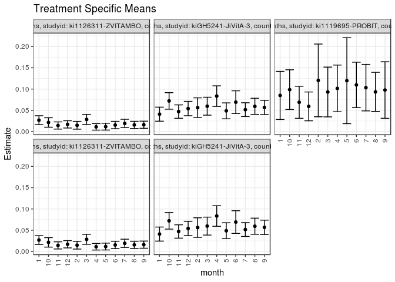

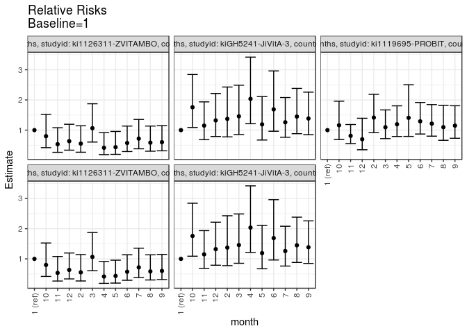

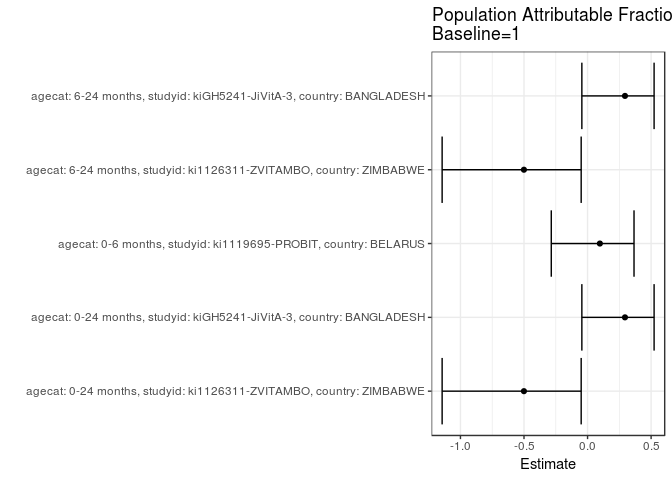

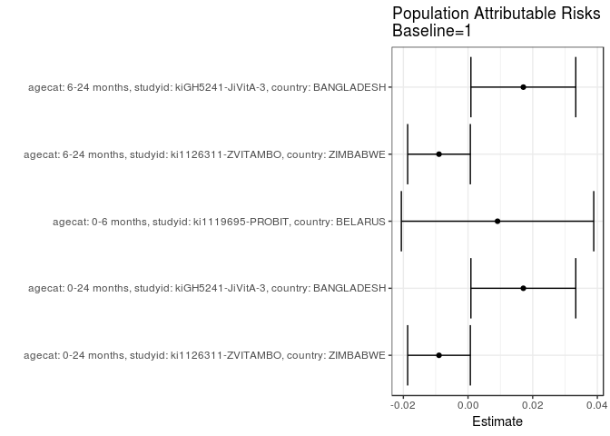

## Results Table

### Parameter: TSM

| agecat | studyid | country | intervention_level | baseline_level | estimate | ci_lower | ci_upper |
| --- | --- | --- | --- | --- | --- | --- | --- |
| 0-24 months | ki1126311-ZVITAMBO | ZIMBABWE | 1 | NA | 0.0269107 | 0.0165042 | 0.0373171 |
| 0-24 months | ki1126311-ZVITAMBO | ZIMBABWE | 2 | NA | 0.0148810 | 0.0057262 | 0.0240357 |
| 0-24 months | ki1126311-ZVITAMBO | ZIMBABWE | 3 | NA | 0.0286458 | 0.0168478 | 0.0404439 |
| 0-24 months | ki1126311-ZVITAMBO | ZIMBABWE | 4 | NA | 0.0111732 | 0.0034737 | 0.0188727 |
| 0-24 months | ki1126311-ZVITAMBO | ZIMBABWE | 5 | NA | 0.0116788 | 0.0036329 | 0.0197247 |
| 0-24 months | ki1126311-ZVITAMBO | ZIMBABWE | 6 | NA | 0.0154440 | 0.0067732 | 0.0241149 |
| 0-24 months | ki1126311-ZVITAMBO | ZIMBABWE | 7 | NA | 0.0193299 | 0.0096423 | 0.0290175 |
| 0-24 months | ki1126311-ZVITAMBO | ZIMBABWE | 8 | NA | 0.0157195 | 0.0072414 | 0.0241975 |
| 0-24 months | ki1126311-ZVITAMBO | ZIMBABWE | 9 | NA | 0.0161663 | 0.0077663 | 0.0245663 |
| 0-24 months | ki1126311-ZVITAMBO | ZIMBABWE | 10 | NA | 0.0215054 | 0.0103616 | 0.0326492 |
| 0-24 months | ki1126311-ZVITAMBO | ZIMBABWE | 11 | NA | 0.0143791 | 0.0059426 | 0.0228156 |
| 0-24 months | ki1126311-ZVITAMBO | ZIMBABWE | 12 | NA | 0.0170455 | 0.0084928 | 0.0255981 |
| 0-24 months | kiGH5241-JiVitA-3 | BANGLADESH | 1 | NA | 0.0410095 | 0.0244665 | 0.0575524 |
| 0-24 months | kiGH5241-JiVitA-3 | BANGLADESH | 2 | NA | 0.0562852 | 0.0332326 | 0.0793377 |
| 0-24 months | kiGH5241-JiVitA-3 | BANGLADESH | 3 | NA | 0.0597668 | 0.0387015 | 0.0808320 |
| 0-24 months | kiGH5241-JiVitA-3 | BANGLADESH | 4 | NA | 0.0834783 | 0.0593205 | 0.1076361 |
| 0-24 months | kiGH5241-JiVitA-3 | BANGLADESH | 5 | NA | 0.0488246 | 0.0301045 | 0.0675447 |
| 0-24 months | kiGH5241-JiVitA-3 | BANGLADESH | 6 | NA | 0.0692168 | 0.0425353 | 0.0958982 |
| 0-24 months | kiGH5241-JiVitA-3 | BANGLADESH | 7 | NA | 0.0516351 | 0.0354509 | 0.0678193 |
| 0-24 months | kiGH5241-JiVitA-3 | BANGLADESH | 8 | NA | 0.0594203 | 0.0404142 | 0.0784264 |
| 0-24 months | kiGH5241-JiVitA-3 | BANGLADESH | 9 | NA | 0.0567867 | 0.0398982 | 0.0736753 |
| 0-24 months | kiGH5241-JiVitA-3 | BANGLADESH | 10 | NA | 0.0721088 | 0.0526696 | 0.0915481 |
| 0-24 months | kiGH5241-JiVitA-3 | BANGLADESH | 11 | NA | 0.0471204 | 0.0314148 | 0.0628260 |
| 0-24 months | kiGH5241-JiVitA-3 | BANGLADESH | 12 | NA | 0.0542005 | 0.0373612 | 0.0710398 |
| 0-6 months | ki1119695-PROBIT | BELARUS | 1 | NA | 0.0850575 | 0.0285236 | 0.1415913 |
| 0-6 months | ki1119695-PROBIT | BELARUS | 2 | NA | 0.1203931 | 0.0349339 | 0.2058523 |
| 0-6 months | ki1119695-PROBIT | BELARUS | 3 | NA | 0.0931677 | 0.0346597 | 0.1516757 |
| 0-6 months | ki1119695-PROBIT | BELARUS | 4 | NA | 0.1015453 | 0.0467029 | 0.1563876 |
| 0-6 months | ki1119695-PROBIT | BELARUS | 5 | NA | 0.1197479 | 0.0187465 | 0.2207493 |
| 0-6 months | ki1119695-PROBIT | BELARUS | 6 | NA | 0.1098266 | 0.0565604 | 0.1630927 |
| 0-6 months | ki1119695-PROBIT | BELARUS | 7 | NA | 0.1033333 | 0.0486790 | 0.1579876 |
| 0-6 months | ki1119695-PROBIT | BELARUS | 8 | NA | 0.0933735 | 0.0474015 | 0.1393455 |
| 0-6 months | ki1119695-PROBIT | BELARUS | 9 | NA | 0.0977199 | 0.0312507 | 0.1641891 |
| 0-6 months | ki1119695-PROBIT | BELARUS | 10 | NA | 0.0986938 | 0.0520343 | 0.1453532 |
| 0-6 months | ki1119695-PROBIT | BELARUS | 11 | NA | 0.0689655 | 0.0313129 | 0.1066181 |
| 0-6 months | ki1119695-PROBIT | BELARUS | 12 | NA | 0.0593220 | 0.0254658 | 0.0931782 |
| 6-24 months | ki1126311-ZVITAMBO | ZIMBABWE | 1 | NA | 0.0269107 | 0.0165042 | 0.0373171 |
| 6-24 months | ki1126311-ZVITAMBO | ZIMBABWE | 2 | NA | 0.0148810 | 0.0057262 | 0.0240357 |
| 6-24 months | ki1126311-ZVITAMBO | ZIMBABWE | 3 | NA | 0.0286458 | 0.0168478 | 0.0404439 |
| 6-24 months | ki1126311-ZVITAMBO | ZIMBABWE | 4 | NA | 0.0111732 | 0.0034737 | 0.0188727 |
| 6-24 months | ki1126311-ZVITAMBO | ZIMBABWE | 5 | NA | 0.0116788 | 0.0036329 | 0.0197247 |
| 6-24 months | ki1126311-ZVITAMBO | ZIMBABWE | 6 | NA | 0.0154440 | 0.0067732 | 0.0241149 |
| 6-24 months | ki1126311-ZVITAMBO | ZIMBABWE | 7 | NA | 0.0193299 | 0.0096423 | 0.0290175 |
| 6-24 months | ki1126311-ZVITAMBO | ZIMBABWE | 8 | NA | 0.0157195 | 0.0072414 | 0.0241975 |
| 6-24 months | ki1126311-ZVITAMBO | ZIMBABWE | 9 | NA | 0.0161663 | 0.0077663 | 0.0245663 |
| 6-24 months | ki1126311-ZVITAMBO | ZIMBABWE | 10 | NA | 0.0215054 | 0.0103616 | 0.0326492 |
| 6-24 months | ki1126311-ZVITAMBO | ZIMBABWE | 11 | NA | 0.0143791 | 0.0059426 | 0.0228156 |
| 6-24 months | ki1126311-ZVITAMBO | ZIMBABWE | 12 | NA | 0.0170455 | 0.0084928 | 0.0255981 |
| 6-24 months | kiGH5241-JiVitA-3 | BANGLADESH | 1 | NA | 0.0410095 | 0.0244665 | 0.0575524 |
| 6-24 months | kiGH5241-JiVitA-3 | BANGLADESH | 2 | NA | 0.0562852 | 0.0332326 | 0.0793377 |
| 6-24 months | kiGH5241-JiVitA-3 | BANGLADESH | 3 | NA | 0.0597668 | 0.0387015 | 0.0808320 |
| 6-24 months | kiGH5241-JiVitA-3 | BANGLADESH | 4 | NA | 0.0834783 | 0.0593205 | 0.1076361 |
| 6-24 months | kiGH5241-JiVitA-3 | BANGLADESH | 5 | NA | 0.0488246 | 0.0301045 | 0.0675447 |
| 6-24 months | kiGH5241-JiVitA-3 | BANGLADESH | 6 | NA | 0.0692168 | 0.0425353 | 0.0958982 |
| 6-24 months | kiGH5241-JiVitA-3 | BANGLADESH | 7 | NA | 0.0516351 | 0.0354509 | 0.0678193 |
| 6-24 months | kiGH5241-JiVitA-3 | BANGLADESH | 8 | NA | 0.0594203 | 0.0404142 | 0.0784264 |
| 6-24 months | kiGH5241-JiVitA-3 | BANGLADESH | 9 | NA | 0.0567867 | 0.0398982 | 0.0736753 |
| 6-24 months | kiGH5241-JiVitA-3 | BANGLADESH | 10 | NA | 0.0721088 | 0.0526696 | 0.0915481 |
| 6-24 months | kiGH5241-JiVitA-3 | BANGLADESH | 11 | NA | 0.0471204 | 0.0314148 | 0.0628260 |
| 6-24 months | kiGH5241-JiVitA-3 | BANGLADESH | 12 | NA | 0.0542005 | 0.0373612 | 0.0710398 |

### Parameter: E(Y)

| agecat | studyid | country | intervention_level | baseline_level | estimate | ci_lower | ci_upper |
| --- | --- | --- | --- | --- | --- | --- | --- |
| 0-24 months | ki1126311-ZVITAMBO | ZIMBABWE | NA | NA | 0.0179338 | 0.0152382 | 0.0206295 |
| 0-24 months | kiGH5241-JiVitA-3 | BANGLADESH | NA | NA | 0.0581186 | 0.0523097 | 0.0639274 |
| 0-6 months | ki1119695-PROBIT | BELARUS | NA | NA | 0.0941866 | 0.0454872 | 0.1428859 |
| 6-24 months | ki1126311-ZVITAMBO | ZIMBABWE | NA | NA | 0.0179338 | 0.0152382 | 0.0206295 |
| 6-24 months | kiGH5241-JiVitA-3 | BANGLADESH | NA | NA | 0.0581186 | 0.0523097 | 0.0639274 |

### Parameter: RR

| agecat | studyid | country | intervention_level | baseline_level | estimate | ci_lower | ci_upper |
| --- | --- | --- | --- | --- | --- | --- | --- |
| 0-24 months | ki1126311-ZVITAMBO | ZIMBABWE | 1 | 1 | 1.0000000 | 1.0000000 | 1.0000000 |
| 0-24 months | ki1126311-ZVITAMBO | ZIMBABWE | 2 | 1 | 0.5529762 | 0.2673804 | 1.1436241 |
| 0-24 months | ki1126311-ZVITAMBO | ZIMBABWE | 3 | 1 | 1.0644792 | 0.6050384 | 1.8728001 |
| 0-24 months | ki1126311-ZVITAMBO | ZIMBABWE | 4 | 1 | 0.4151955 | 0.1883977 | 0.9150184 |
| 0-24 months | ki1126311-ZVITAMBO | ZIMBABWE | 5 | 1 | 0.4339854 | 0.1969539 | 0.9562811 |
| 0-24 months | ki1126311-ZVITAMBO | ZIMBABWE | 6 | 1 | 0.5738996 | 0.2902458 | 1.1347650 |
| 0-24 months | ki1126311-ZVITAMBO | ZIMBABWE | 7 | 1 | 0.7182990 | 0.3814069 | 1.3527638 |
| 0-24 months | ki1126311-ZVITAMBO | ZIMBABWE | 8 | 1 | 0.5841354 | 0.3008132 | 1.1343058 |
| 0-24 months | ki1126311-ZVITAMBO | ZIMBABWE | 9 | 1 | 0.6007390 | 0.3143337 | 1.1481028 |
| 0-24 months | ki1126311-ZVITAMBO | ZIMBABWE | 10 | 1 | 0.7991398 | 0.4186195 | 1.5255486 |
| 0-24 months | ki1126311-ZVITAMBO | ZIMBABWE | 11 | 1 | 0.5343268 | 0.2646251 | 1.0789043 |
| 0-24 months | ki1126311-ZVITAMBO | ZIMBABWE | 12 | 1 | 0.6334091 | 0.3361762 | 1.1934429 |
| 0-24 months | kiGH5241-JiVitA-3 | BANGLADESH | 1 | 1 | 1.0000000 | 1.0000000 | 1.0000000 |
| 0-24 months | kiGH5241-JiVitA-3 | BANGLADESH | 2 | 1 | 1.3724923 | 0.7757726 | 2.4282051 |
| 0-24 months | kiGH5241-JiVitA-3 | BANGLADESH | 3 | 1 | 1.4573894 | 0.8538090 | 2.4876569 |
| 0-24 months | kiGH5241-JiVitA-3 | BANGLADESH | 4 | 1 | 2.0355851 | 1.2121416 | 3.4184181 |
| 0-24 months | kiGH5241-JiVitA-3 | BANGLADESH | 5 | 1 | 1.1905688 | 0.6714765 | 2.1109511 |
| 0-24 months | kiGH5241-JiVitA-3 | BANGLADESH | 6 | 1 | 1.6878238 | 0.9619935 | 2.9612979 |
| 0-24 months | kiGH5241-JiVitA-3 | BANGLADESH | 7 | 1 | 1.2591022 | 0.7621072 | 2.0802038 |
| 0-24 months | kiGH5241-JiVitA-3 | BANGLADESH | 8 | 1 | 1.4489408 | 0.8815967 | 2.3813942 |
| 0-24 months | kiGH5241-JiVitA-3 | BANGLADESH | 9 | 1 | 1.3847218 | 0.8489123 | 2.2587190 |
| 0-24 months | kiGH5241-JiVitA-3 | BANGLADESH | 10 | 1 | 1.7583462 | 1.0874010 | 2.8432762 |
| 0-24 months | kiGH5241-JiVitA-3 | BANGLADESH | 11 | 1 | 1.1490132 | 0.6820965 | 1.9355491 |
| 0-24 months | kiGH5241-JiVitA-3 | BANGLADESH | 12 | 1 | 1.3216592 | 0.7888566 | 2.2143228 |
| 0-6 months | ki1119695-PROBIT | BELARUS | 1 | 1 | 1.0000000 | 1.0000000 | 1.0000000 |
| 0-6 months | ki1119695-PROBIT | BELARUS | 2 | 1 | 1.4154326 | 0.9165360 | 2.1858930 |
| 0-6 months | ki1119695-PROBIT | BELARUS | 3 | 1 | 1.0953500 | 0.7188813 | 1.6689704 |
| 0-6 months | ki1119695-PROBIT | BELARUS | 4 | 1 | 1.1938428 | 0.7900747 | 1.8039570 |
| 0-6 months | ki1119695-PROBIT | BELARUS | 5 | 1 | 1.4078469 | 0.7915262 | 2.5040648 |
| 0-6 months | ki1119695-PROBIT | BELARUS | 6 | 1 | 1.2912045 | 0.8700137 | 1.9163020 |
| 0-6 months | ki1119695-PROBIT | BELARUS | 7 | 1 | 1.2148649 | 0.7995177 | 1.8459838 |
| 0-6 months | ki1119695-PROBIT | BELARUS | 8 | 1 | 1.0977695 | 0.6620963 | 1.8201247 |
| 0-6 months | ki1119695-PROBIT | BELARUS | 9 | 1 | 1.1488687 | 0.7301773 | 1.8076423 |
| 0-6 months | ki1119695-PROBIT | BELARUS | 10 | 1 | 1.1603185 | 0.6877784 | 1.9575188 |
| 0-6 months | ki1119695-PROBIT | BELARUS | 11 | 1 | 0.8108108 | 0.5548865 | 1.1847723 |
| 0-6 months | ki1119695-PROBIT | BELARUS | 12 | 1 | 0.6974347 | 0.3492770 | 1.3926343 |
| 6-24 months | ki1126311-ZVITAMBO | ZIMBABWE | 1 | 1 | 1.0000000 | 1.0000000 | 1.0000000 |
| 6-24 months | ki1126311-ZVITAMBO | ZIMBABWE | 2 | 1 | 0.5529762 | 0.2673804 | 1.1436241 |
| 6-24 months | ki1126311-ZVITAMBO | ZIMBABWE | 3 | 1 | 1.0644792 | 0.6050384 | 1.8728001 |
| 6-24 months | ki1126311-ZVITAMBO | ZIMBABWE | 4 | 1 | 0.4151955 | 0.1883977 | 0.9150184 |
| 6-24 months | ki1126311-ZVITAMBO | ZIMBABWE | 5 | 1 | 0.4339854 | 0.1969539 | 0.9562811 |
| 6-24 months | ki1126311-ZVITAMBO | ZIMBABWE | 6 | 1 | 0.5738996 | 0.2902458 | 1.1347650 |
| 6-24 months | ki1126311-ZVITAMBO | ZIMBABWE | 7 | 1 | 0.7182990 | 0.3814069 | 1.3527638 |
| 6-24 months | ki1126311-ZVITAMBO | ZIMBABWE | 8 | 1 | 0.5841354 | 0.3008132 | 1.1343058 |
| 6-24 months | ki1126311-ZVITAMBO | ZIMBABWE | 9 | 1 | 0.6007390 | 0.3143337 | 1.1481028 |
| 6-24 months | ki1126311-ZVITAMBO | ZIMBABWE | 10 | 1 | 0.7991398 | 0.4186195 | 1.5255486 |
| 6-24 months | ki1126311-ZVITAMBO | ZIMBABWE | 11 | 1 | 0.5343268 | 0.2646251 | 1.0789043 |
| 6-24 months | ki1126311-ZVITAMBO | ZIMBABWE | 12 | 1 | 0.6334091 | 0.3361762 | 1.1934429 |
| 6-24 months | kiGH5241-JiVitA-3 | BANGLADESH | 1 | 1 | 1.0000000 | 1.0000000 | 1.0000000 |
| 6-24 months | kiGH5241-JiVitA-3 | BANGLADESH | 2 | 1 | 1.3724923 | 0.7757726 | 2.4282051 |
| 6-24 months | kiGH5241-JiVitA-3 | BANGLADESH | 3 | 1 | 1.4573894 | 0.8538090 | 2.4876569 |
| 6-24 months | kiGH5241-JiVitA-3 | BANGLADESH | 4 | 1 | 2.0355851 | 1.2121416 | 3.4184181 |
| 6-24 months | kiGH5241-JiVitA-3 | BANGLADESH | 5 | 1 | 1.1905688 | 0.6714765 | 2.1109511 |
| 6-24 months | kiGH5241-JiVitA-3 | BANGLADESH | 6 | 1 | 1.6878238 | 0.9619935 | 2.9612979 |
| 6-24 months | kiGH5241-JiVitA-3 | BANGLADESH | 7 | 1 | 1.2591022 | 0.7621072 | 2.0802038 |
| 6-24 months | kiGH5241-JiVitA-3 | BANGLADESH | 8 | 1 | 1.4489408 | 0.8815967 | 2.3813942 |
| 6-24 months | kiGH5241-JiVitA-3 | BANGLADESH | 9 | 1 | 1.3847218 | 0.8489123 | 2.2587190 |
| 6-24 months | kiGH5241-JiVitA-3 | BANGLADESH | 10 | 1 | 1.7583462 | 1.0874010 | 2.8432762 |
| 6-24 months | kiGH5241-JiVitA-3 | BANGLADESH | 11 | 1 | 1.1490132 | 0.6820965 | 1.9355491 |
| 6-24 months | kiGH5241-JiVitA-3 | BANGLADESH | 12 | 1 | 1.3216592 | 0.7888566 | 2.2143228 |

### Parameter: PAR

| agecat | studyid | country | intervention_level | baseline_level | estimate | ci_lower | ci_upper |
| --- | --- | --- | --- | --- | --- | --- | --- |
| 0-24 months | ki1126311-ZVITAMBO | ZIMBABWE | 1 | NA | -0.0089768 | -0.0186697 | 0.0007161 |
| 0-24 months | kiGH5241-JiVitA-3 | BANGLADESH | 1 | NA | 0.0171091 | 0.0008910 | 0.0333272 |
| 0-6 months | ki1119695-PROBIT | BELARUS | 1 | NA | 0.0091291 | -0.0206251 | 0.0388833 |
| 6-24 months | ki1126311-ZVITAMBO | ZIMBABWE | 1 | NA | -0.0089768 | -0.0186697 | 0.0007161 |
| 6-24 months | kiGH5241-JiVitA-3 | BANGLADESH | 1 | NA | 0.0171091 | 0.0008910 | 0.0333272 |

### Parameter: PAF

| agecat | studyid | country | intervention_level | baseline_level | estimate | ci_lower | ci_upper |
| --- | --- | --- | --- | --- | --- | --- | --- |
| 0-24 months | ki1126311-ZVITAMBO | ZIMBABWE | 1 | NA | -0.5005511 | -1.1440733 | -0.0501757 |
| 0-24 months | kiGH5241-JiVitA-3 | BANGLADESH | 1 | NA | 0.2943826 | -0.0448415 | 0.5234722 |
| 0-6 months | ki1119695-PROBIT | BELARUS | 1 | NA | 0.0969257 | -0.2854184 | 0.3655426 |
| 6-24 months | ki1126311-ZVITAMBO | ZIMBABWE | 1 | NA | -0.5005511 | -1.1440733 | -0.0501757 |
| 6-24 months | kiGH5241-JiVitA-3 | BANGLADESH | 1 | NA | 0.2943826 | -0.0448415 | 0.5234722 |